# comparingGWASresults

```python
import os
import pandas as pd
```

## 1. Reading Data

## FastLMM

```python
fastlmmData = pd.read_csv('FastLLM_GWAS.tsv', sep='\t')
fastlmmData = fastlmmData.dropna(subset=['PValue'])
fastlmmData.head()
```

|  | Unnamed: 0 | sid_index | SNP | Chr | GenDist | ChrPos | PValue | SnpWeight | SnpWeightSE | EffectSize | Mixing | Nullh2 | Pheno | PhenoCount |
| --- | --- | --- | --- | --- | --- | --- | --- | --- | --- | --- | --- | --- | --- | --- |
| 0 | 0 | 140097 | 2_27068344_C_G | 2.0 | NaN | 27068344.0 | 9.818765e-07 | 2.930856 | 0.525395 | 0.141419 | 0 | 0.0 | pheno3 | 4 |
| 1 | 1 | 10405 | 8_2256392_T_C | 8.0 | NaN | 2256392.0 | 1.481066e-06 | -2.571919 | 0.470873 | 0.163033 | 0 | 0.0 | pheno3 | 4 |
| 2 | 2 | 92561 | 5_13461911_C_A | 5.0 | NaN | 13461911.0 | 1.710888e-06 | -3.290962 | 0.607069 | 0.150151 | 0 | 0.0 | pheno3 | 4 |
| 3 | 3 | 157097 | 14_21361942_T_A | 14.0 | NaN | 21361942.0 | 1.721902e-06 | 5.262175 | 0.971016 | 0.564093 | 0 | 0.0 | pheno3 | 4 |
| 4 | 4 | 150762 | 5_21106423_C_G | 5.0 | NaN | 21106423.0 | 2.134527e-06 | -2.932032 | 0.547211 | 0.068131 | 0 | 0.0 | pheno3 | 4 |

## Plink 1.07 without correction for population structure

```python
plink107DataWithout = pd.read_csv('plink1.07_untwsit54/plink1.07_untwsit54.qassoc', sep='\s+|\t', engine='python')
plink107DataWithout = plink107DataWithout.dropna(subset=['P'])
plink107DataWithout.head()
```

|  | CHR | SNP | BP | NMISS | BETA | SE | R2 | T | P |
| --- | --- | --- | --- | --- | --- | --- | --- | --- | --- |
| 4 | 1 | 1_2713_C_T | 2713 | 3 | 3.0630 | 4.5250 | 0.31420 | 0.6768 | 0.6212 |
| 6 | 1 | 1_3345_C_T | 3345 | 20 | 1.5610 | 1.5040 | 0.05648 | 1.0380 | 0.3130 |
| 7 | 1 | 1_3463_C_T | 3463 | 43 | 0.7098 | 0.9726 | 0.01283 | 0.7299 | 0.4696 |
| 24 | 1 | 1_5599_C_G | 5599 | 53 | -1.0120 | 0.9971 | 0.01978 | -1.0140 | 0.3151 |
| 32 | 1 | 1_6092_G_A | 6092 | 54 | -0.3755 | 1.3960 | 0.00139 | -0.2691 | 0.7889 |

## Plink 1.07 with correction for population structure

```python
plink107DataWith = pd.read_csv('plink1.07_untwsit54_corrected/plink1.07_untwsit54_corrected.assoc.linear', sep='\s+|\t', engine='python')
plink107DataWith = plink107DataWith.dropna(subset=['P'])
plink107DataWith.head()
```

|  | CHR | SNP | BP | A1 | TEST | NMISS | BETA | STAT | P |
| --- | --- | --- | --- | --- | --- | --- | --- | --- | --- |
| 6 | 1 | 1_3345_C_T | 3345 | C | ADD | 20 | 0.40950 | 1.5870 | 0.1320 |
| 7 | 1 | 1_3463_C_T | 3463 | C | ADD | 43 | 0.11730 | 0.7364 | 0.4659 |
| 24 | 1 | 1_5599_C_G | 5599 | C | ADD | 53 | -0.13760 | -0.9716 | 0.3360 |
| 32 | 1 | 1_6092_G_A | 6092 | G | ADD | 54 | -0.07016 | -0.4978 | 0.6208 |
| 35 | 1 | 1_7785_T_A | 7785 | T | ADD | 53 | -0.10360 | -0.7368 | 0.4647 |

## Plink 1.9 without correction for population structure

```python
plink19DataWithout = pd.read_csv('plink19_untwsit54/plink19_untwsit54.qassoc', sep='\s+|\t', engine='python')
plink19DataWithout = plink19DataWithout.dropna(subset=['P'])
plink19DataWithout.head()
```

|  | CHR | SNP | BP | NMISS | BETA | SE | R2 | T | P |
| --- | --- | --- | --- | --- | --- | --- | --- | --- | --- |
| 0 | 17 | 17_54_C_G | 54 | 53 | 2.5810 | 2.317000e+00 | 2.375000e-02 | 1.114000 | 0.2705 |
| 6 | 17 | 17_458_T_C | 458 | 49 | -128.0000 | 3.915000e+07 | 2.274000e-13 | -0.000003 | 1.0000 |
| 11 | 17 | 17_784_A_C | 784 | 53 | 4.0490 | 3.236000e+00 | 2.979000e-02 | 1.251000 | 0.2165 |
| 20 | 17 | 17_1709_G_A | 1709 | 53 | 1.6740 | 1.074000e+00 | 4.552000e-02 | 1.560000 | 0.1251 |
| 21 | 17 | 17_1717_A_G | 1717 | 7 | 0.1333 | 2.060000e+00 | 8.370000e-04 | 0.064720 | 0.9509 |

## Plink 1.9 with correction for population structure

```python
plink19DataWith = pd.read_csv('plink19_untwsit54_corrected/plink19_untwsit54_corrected.assoc.linear', sep='\s+|\t', engine='python')
plink19DataWith = plink19DataWith.dropna(subset=['P'])
plink19DataWith.head()
```

|  | CHR | SNP | BP | A1 | TEST | NMISS | BETA | STAT | P |
| --- | --- | --- | --- | --- | --- | --- | --- | --- | --- |
| 0 | 17 | 17_54_C_G | 54 | C | ADD | 53 | 0.1264 | 0.8937 | 0.37580 |
| 11 | 17 | 17_784_A_C | 784 | A | ADD | 53 | 0.1512 | 1.0800 | 0.28550 |
| 20 | 17 | 17_1709_G_A | 1709 | G | ADD | 53 | 0.2887 | 2.0270 | 0.04808 |
| 22 | 17 | 17_1752_G_T | 1752 | G | ADD | 54 | 0.3059 | 2.2240 | 0.03071 |
| 27 | 17 | 17_2454_T_C | 2454 | T | ADD | 51 | 0.1247 | 0.8752 | 0.38590 |

## Plink1.07_Web without correction for population structure

##### NOTE: for the web version the table look a bit different from above, is because i need only these two columns for further analysis and to improve efficiency wihting javascript I discard the rest

```python
plink107_Web_Without = pd.read_csv('PlinkWeb_untwist54/plinkWeb1.07_without_correction.qassoc', sep='\s+|\t', engine='python')
plink107_Web_Without = plink107_Web_Without.dropna(subset=['P'])
plink107_Web_Without.P = [float(i.strip('"')) for i in plink107_Web_Without.P]
plink107_Web_Without.SNP = [i.strip('"') for i in plink107_Web_Without.SNP]

plink107_Web_Without.head()
```

|  | SNP | P |
| --- | --- | --- |
| 0 | 1_2713_C_T | 0.6212 |
| 1 | 1_3345_C_T | 0.3130 |
| 2 | 1_3463_C_T | 0.4696 |
| 3 | 1_5599_C_G | 0.3151 |
| 4 | 1_6092_G_A | 0.7889 |

## Plink1.07_Web with correction for population structure

```python
plink107_Web_With = pd.read_csv('PlinkWeb_untwist54/plinkWeb1.07_with_correction.qassoc.tsv', sep='\s+|\t', engine='python')
plink107_Web_With = plink107_Web_With.dropna(subset=['P'])
plink107_Web_With.P = [float(i.strip('"')) for i in plink107_Web_With.P]
plink107_Web_With.SNP = [i.strip('"') for i in plink107_Web_With.SNP]
plink107_Web_With.head()
```

|  | SNP | P |
| --- | --- | --- |
| 0 | 1_3345_C_T | 0.1320 |
| 1 | 1_3463_C_T | 0.4659 |
| 2 | 1_5599_C_G | 0.3360 |
| 3 | 1_6092_G_A | 0.6208 |
| 4 | 1_7785_T_A | 0.4647 |

## 2. Results

## Comparison Table

```python
import pandas as pd

def sigHits(df, colName, threshold):
    return sum(df[colName] < threshold)

association_thresholds = [5e-8, 5e-7, 5e-6, 5e-5]

results = []

for threshold in association_thresholds:
    results.append({
        "Threshold": threshold,
        "Fastlmm": sigHits(fastlmmData, "PValue", threshold),
        "Plink1.07_CLI_without": sigHits(plink107DataWithout, "P", threshold),
        "Plink1.07_CLI_with": sigHits(plink107DataWith, "P", threshold),
        "Plink1.9_CLI_without": sigHits(plink19DataWithout, "P", threshold),
        "Plink1.9_CLI_with": sigHits(plink19DataWith, "P", threshold),
        "Plink1.07_WEB_without": sigHits(plink107_Web_Without, "P", threshold),
        "Plink1.07_WEB_with": sigHits(plink107_Web_With, "P", threshold)

    })

results_df = pd.DataFrame(results)
results_df
```

|  | Threshold | Fastlmm | Plink1.07_CLI_without | Plink1.07_CLI_with | Plink1.9_CLI_without | Plink1.9_CLI_with | Plink1.07_WEB_without | Plink1.07_WEB_with |
| --- | --- | --- | --- | --- | --- | --- | --- | --- |
| 0 | 5.000000e-08 | 0 | 1 | 0 | 0 | 0 | 1 | 0 |
| 1 | 5.000000e-07 | 0 | 6 | 1 | 6 | 2 | 6 | 1 |
| 2 | 5.000000e-06 | 30 | 45 | 15 | 46 | 24 | 45 | 15 |
| 3 | 5.000000e-05 | 303 | 260 | 171 | 261 | 284 | 260 | 171 |

Table 1: The above table compares the number of SNPs that reached significane at a given association threshold (AT). Fastlmm results are corrected for population structure using relationship matrix, which is inernally calculated by fastlmm package. In the headers suffixes with and without stand for GWAS runs with and without correction for population structure. The results indicate that default value of AT (5*10^-8) yielded same results when corrected for population structure for all methods. An AT of 5*10^-07 also produced similar results for population corrected GWAS, however fastlmm was more stringent. At more relaxed values of AT yield varying results at respective implementations.

## Plots

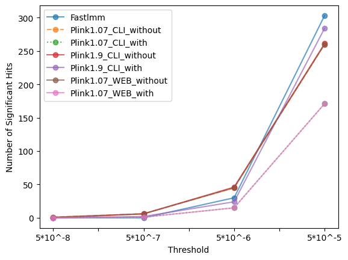

```python
import pandas as pd
import matplotlib.pyplot as plt
from matplotlib.ticker import ScalarFormatter

# Assuming results_df is defined with the Threshold column as strings
results_df.Threshold = ["5*10^-8", "5*10^-7", "5*10^-6", "5*10^-5"]

# Plotting with different markers for each category
ax = results_df.plot(x='Threshold', y=["Fastlmm",
                                       "Plink1.07_CLI_without",
                                       "Plink1.07_CLI_with",
                                       "Plink1.9_CLI_without",
                                       "Plink1.9_CLI_with",
                                       "Plink1.07_WEB_without",
                                       "Plink1.07_WEB_with"],
                     marker='o', alpha=0.7, style=['-', '--', ':'])

ax.set_ylabel('Number of Significant Hits')
ax.set_xlabel('Threshold')

plt.show()
```

```python
import plotly.graph_objects as go
fig = go.Figure()

columns_to_plot = results_df.columns[1:]  # Exclude 'Threshold' from columns

for column in columns_to_plot:
    fig.add_trace(go.Bar(x=results_df['Threshold'], y=results_df[column], name=column))

# Update layout
fig.update_layout(barmode='group',
                  title='<b>Number of significant SNPs at a given threshold</b>',
                  xaxis_title='<b>Threshold</b>',
                  yaxis_title='<b>Count</b>',
                 title_x=0.45)

# Show the plot
fig.show()
```

[interactive chart not shown]

## Qualitative comparison

Below is a qualtitive comparison of GWAS results from different implementations with our web based plink tool using an UpSet plot. The comparison highlight the number of loci commonly found to be associated with a given implementations at a specific pvalue threshold for association.

```python
import pandas as pd
from matplotlib import pyplot as plt
from matplotlib import pyplot
from upsetplot import plot
from upsetplot import from_contents


def sigSNPlist(df, colName, threshold):
    df = df[df[colName] < threshold]
    return list(df.SNP)

association_thresholds = [5e-8, 5e-7, 5e-6, 5e-5]

data = dict()

for threshold in association_thresholds:
        data[threshold] = {}

        data[threshold]["Fastlmm"] = sigSNPlist(fastlmmData, "PValue", threshold)
        data[threshold]["Plink1.07_CLI_without"] = sigSNPlist(plink107DataWithout, "P", threshold)
        data[threshold]["Plink1.07_CLI_with"] = sigSNPlist(plink107DataWith, "P", threshold)
        data[threshold]["Plink1.9_CLI_without"] = sigSNPlist(plink19DataWithout, "P", threshold)
        data[threshold]["Plink1.9_CLI_with"] = sigSNPlist(plink19DataWith, "P", threshold)
        data[threshold]["Plink1.07_WEB_without"] = sigSNPlist(plink107_Web_Without, "P", threshold)
        data[threshold]["Plink1.07_WEB_with"] = sigSNPlist(plink107_Web_With, "P", threshold)
def createUpsetPlot(threshold):
    # Your data
    sets = data[threshold]
    dataUpsetPlot = from_contents({'Fastlmm': sets['Fastlmm'],
                          'Plink1.07_CLI_without': sets['Plink1.07_CLI_without'],
                          'Plink1.07_CLI_with': sets['Plink1.07_CLI_with'],
                          'Plink1.9_CLI_without': sets['Plink1.9_CLI_without'],
                          'Plink1.9_CLI_with': sets['Plink1.9_CLI_with'],
                          'Plink1.07_WEB_without': sets['Plink1.07_WEB_without'],
                          'Plink1.07_WEB_with': sets['Plink1.07_WEB_with'],
                         })


    plot(dataUpsetPlot)
    plt.title(f'Intersection of results at pvalues threshold of {threshold}')
    pyplot.show()
```

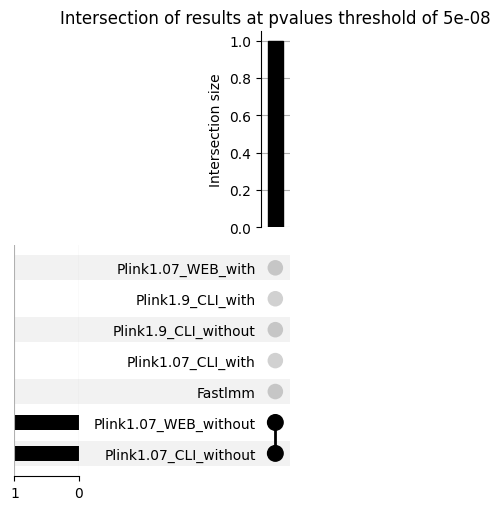

```python
createUpsetPlot(5e-8)
```

Figure 3. Comparison of different implementations of GWA methods with our web based plink tool with an UpSet plot. The plot represents that there is an overlap of only one SNP locus between the implementations connected via black dots. All other implementations do not yield any significant SNPs at this threshold (5*10^-8)

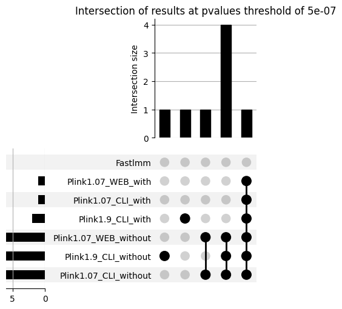

```python
createUpsetPlot(5e-7)
```

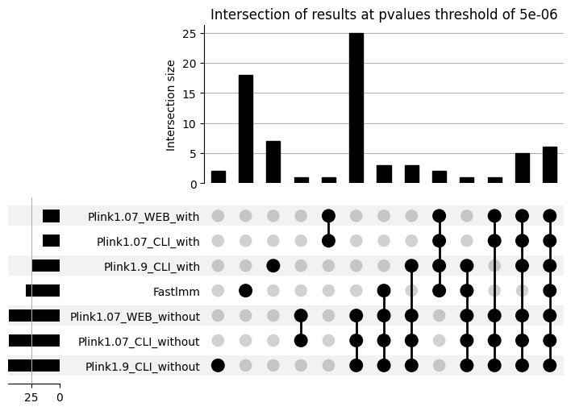

```python
createUpsetPlot(5e-6)
```

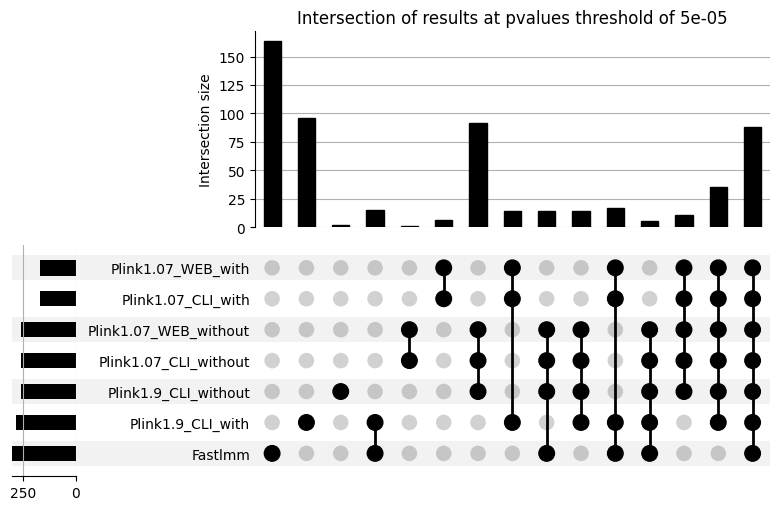

```python
createUpsetPlot(5e-5)
```